# Rozvojová studia (augustový turnus)

Zpět na rozcestník zpětné vazby | Tento report we Wordu | Data v CSV

## Hodnocení kurzu

Průměrná známka:

| Blok setkání | Průměrná známka |
| --- | --- |
| A | 1.38 |
| B | 1.25 |
| oba | 1.33 |

### Hodnocení po dnech

A a B jsou bloky (A je 9-10:30, B je 11-12:30)

Známky jsou jako ve škole: 1 je nejlepší, 5 nejhorší

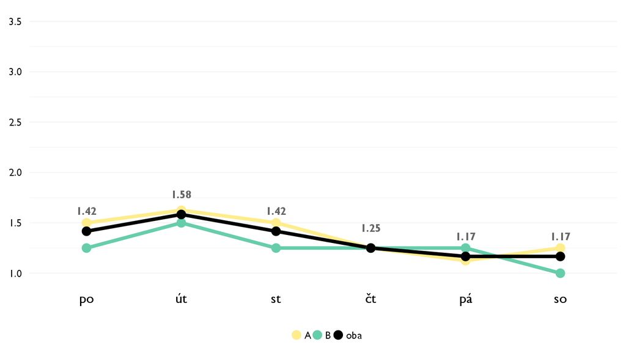

### Co se na kurzu líbilo

- dobrá štruktúra so stylizovaným faktom a skupinovými aktivitami, veľký záber tém
- Nejradsi jsem mnela pocatecni diskuze a obhajovani sveho postoje, take se mi libila prace ve skupinach, kde byl prostor pro navrhnuti vlastnich reseni pro probelmi rozvojovych zemi.
- Způsob vedení kurzu, témata.
- Kopec nových informácií a tiež to, že Vašek dával príklady z vlastnej skúsenosti.
- najviac sa mi na tomto kurze pacili vaskove skusenoti s rozvojovymi zemami z prvej ruky, ktore nam skvelo vedel podat.
- Kurz bol faktický, čo bolo dobré.
- Dozvedela som sa nové informácie, ktoré by som sa nikde inde nedozvedela alebo by som sa nad nimi nezamýšľala.
- Miluju rozvojová studia s Vaškem <3
- Roznorodost tem, zapojenie vsetkych do aktivit. Velmi zaujimave.
- Rozvojova pomoc
- prace v skupinach
- Mel dobry pomer informativnosti a vymysleni z toho plynoucich problemu a reseni.

### Co na kurzu změnit

- Kurz mi velmi vyhovoval, mozna bych v ramci uvodu zaradila zbezne popsani jednotlivych zemi a jejich problemu.
- Absolútne nič.
- nic! Jen chci víc času, hodina a pôl je málo.
- Nic mi nenapada.
- Nic
- zvysit narocnost
- Lekce bez powerpointu byla nejvice fajn, protoze fakta byla recena rychleji a mohli jsme vice diskutovat.

## Hodnocení lektora

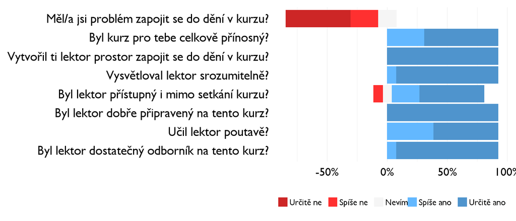

### Komentáře k lektorovi

- Bylo to super…velmi ocenuji ze hodina mnela jasne danou strukturu, ale zaroven byl cas na volnou diskuzi a kreativitu.
- Je proste super
- Dakujem!
- Ze zacatku to bylo trochu chaoticke a nesedelo casove rozvrzeni, ale tak to bylo jen prvni den. Mozna bych uvitala jeste vice navadeni, at na veci prichazime sami a take by bylo super, kdyby nam vice oponoval v tom, s cim prichazime.

## Náročnost kurzu

### **Jak hodnotíš náročnost…**

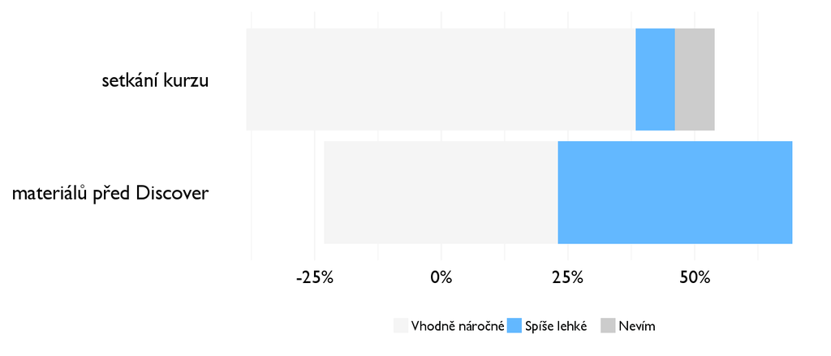

## Didaktika

Na některé otázky jsme se na augustovém turnuse neptali - tam uvidíte nadpis bez grafu.

### Jak lektor učí a měl by to změnit?

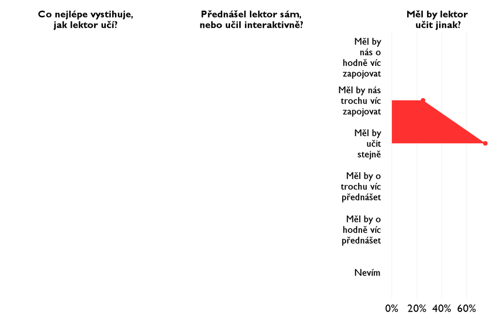

### Jak se studentům nejlépe učí?

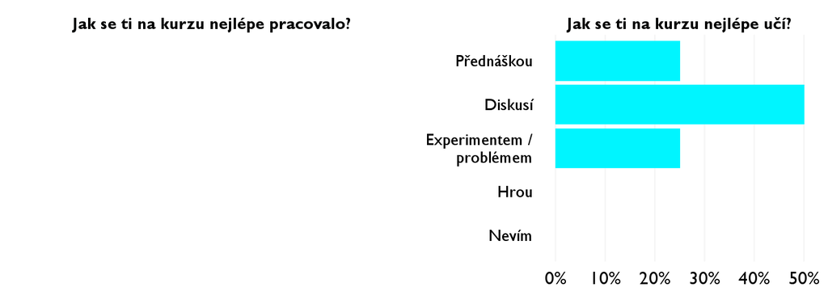

## Ovlivnil tě kurz nějak?

**Pokud ano, jak? Pokud ne, proč ne?**

- ovplyvnil celý môjn názor na problematiku a dal mi veľa pohľadov ako sa pozerať na problémy
- Tento kurz mi ukazal ze nejsem jediny clovek, ktery si mysli ze rozvojovou pomoc je dulezite dobre planovat a ze zahrnuje mnohem vce aspektu nez se bezne prezentuje.
- Uvědomil jsem si spoustu souvislostí a dostal na problematiku nový náhled.
- Určite áno. Dalo mi to nový pohľad na danú problematiku a mnoho podnetov na rozmýšlanie.
- Urcite ma ovplyvnil v mojom vnimani sveta, ohlade na rozvojove krajiny, problemy ludi tychto regionov a v neposlednom rade aj vo vybere mojho dalsieho smerovania.
- Utvrdil ma v tom, že chcem skúsiť pracovať v rozvojovej krajine.
- Ukázal mi krajiny o ktorých som nič nevedela a pomohol mi pochopiť ľudí ktorí tam žijú.
- Asi neovlivnil, ale rozšíril obzory ve vecech co jsem nikdy neslyšela.
- Zmenil moj pohlad na rovojove staty a tuto problematiku.
- Zkusit se podivat do rozvojovych zemi
- ano, prehlad o rozvojovom svete
- Mam realnejsi predstavu o rozvojovem svete, takhze budu schopnejsi si vytvorit a obhajit nazor na temata 3. sveta se tykajici. Take se mozna budu vice zamyslet, jak moje ciny ovlivni soucasnou situaci.